# VEHÍCULOS REGISTRADOS EN EL RUNT DIARIAMENTE

## MODELAMIENTO ESTADÍSTICO

El modelamiento estadístico, en esencia, es una forma de representar matemáticamente sistemas o procesos con el objetivo de describir y explicar su comportamiento, usando conjuntos de datos observados y realizando suposiciones sobre la distribución del proceso que a estos genera. Esta hipotetización es necesaria puesto que siempre está presente un grado de incertidumbre asociado a la naturaleza de los datos y a factores que no se tienen en cuenta durante su recolección, que implican que un conjunto de datos pueda ser explicado por muchos modelos diferentes.

Para el ajuste de un modelo es necesario:

- Escoger el conjunto de datos a quienes se espera el modelo explique.
- Plantear un modelo teórico que se pretenda validar.
- Resolver numericamente las ecuaciones que el modelo plantea.
- Evaluar la validez del modelo en base a los supuestos realizados, al ajuste que este haga de los datos y a la calidad de las predicciones que sea capaz de hacer.
- Interpretar los resultados

# Descripción de la variable respuesta

La variable que se busca explicar con el modelo propuesto en este trabajo es el “Nivel de satisfacción de vida de una madre soltera en Colombia”, usando como fuente de datos la Encuesta Nacional de Calidad de Vida 2017 hecha por el Departamento Administrativo Nacional de Estadística DANE.

Dicha satisfacción es, de acuerdo a la ficha metodológica de la encuesta una variable categórica que toma como valores los números enteros de 0 a 10 donde: 0 es “Totalmente insatisfecho” y 10 es “Totalmente satisfecho”. Es decir, la variable toma valores en una escala arbitraria donde el orden de los niveles en esta es importante.

Para modelar este tipo de variables se emplea a menudo la regresión ordinal, sin embargo es posible realizar otro tipo de procedimientos que tras la transformación de la variable respuesta de forma apropiada resultan útiles como son la regresión Beta o incluso la regresión lineal.

En estos tipos de regresión las variables que se usan como predictoras pueden ser continuas o categóricas(representadas por variables indicadoras), mientras que la respuesta se puede modelar de ambas formas dependiendo de la estrategia escogida, como se describió previamente.

En R se encuentran implementados estos métodos por funciones en diversos paquetes: betareg, MASS, mvord, rms,VGAM, gamlss, entre otros.

En este trabajo se modeló la respuesta, mediante la regresión lineal múltiple.

Se evidencia que en el conjunto de datos no hay registros de una madre soltera totalmente insatisfecha con su vida.

```
##   0   1   2   3   4   5   6   7   8   9  10
##   0   1   0   1   3   7  15  33  81  90 241
```

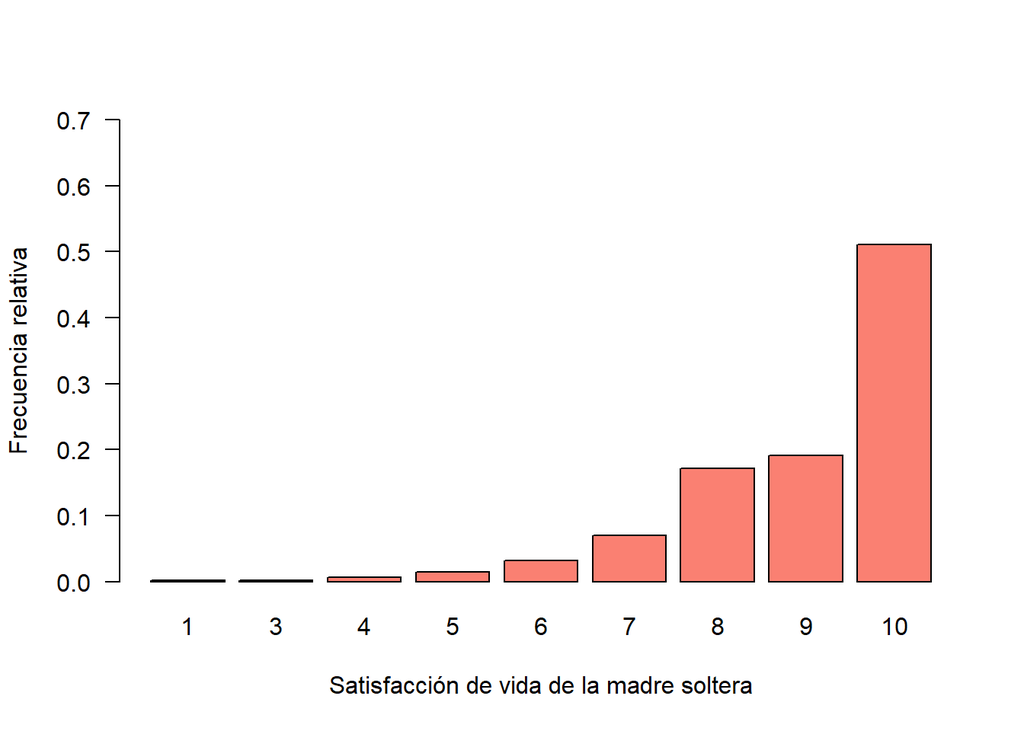

# Ajuste del modelo.

```r
modelo<-lm(SATISFACCION_VIDA~ AÑOS_CUMPLIDOS+ CANT_PERSONAS+
              +INGRESO_HOGAR+COMIDA+HIJOS+TIPO_VIVIENDA+
              SATISFACCCION_INGRESO,
            data=datos)
```

```
##
## Call:
## lm(formula = SATISFACCION_VIDA ~ AÑOS_CUMPLIDOS + CANT_PERSONAS +
##     +INGRESO_HOGAR + COMIDA + HIJOS + TIPO_VIVIENDA + SATISFACCCION_INGRESO,
##     data = datos)
##
## Residuals:
##     Min      1Q  Median      3Q     Max
## -6.9785 -0.6873  0.3465  0.9026  2.4350
##
## Coefficients:
##                        Estimate Std. Error t value Pr(>|t|)
## (Intercept)            6.679513   0.582590  11.465  < 2e-16 ***
## AÑOS_CUMPLIDOS        -0.007200   0.004041  -1.782 0.075445 .
## CANT_PERSONAS         -0.095471   0.039018  -2.447 0.014780 *
## INGRESO_HOGAR          0.366257   0.109979   3.330 0.000937 ***
## COMIDA                 0.483151   0.241752   1.999 0.046241 *
## HIJOS                  0.142186   0.088573   1.605 0.109107
## TIPO_VIVIENDA          0.319434   0.113169   2.823 0.004968 **
## SATISFACCCION_INGRESO  0.114428   0.023902   4.787 2.28e-06 ***
## ---
## Signif. codes:  0 '***' 0.001 '**' 0.01 '*' 0.05 '.' 0.1 ' ' 1
##
## Residual standard error: 1.273 on 464 degrees of freedom
## Multiple R-squared:  0.1418, Adjusted R-squared:  0.1289
## F-statistic: 10.95 on 7 and 464 DF,  p-value: 7.895e-13
```

En un modelo de regresión el R cuadrado ajustado es el porcentaje de variación en la variable de respuesta que es explicado por su relación con una o más variables predictoras, ajustado para el número de predictores en el modelo. En el modelo presentado es evidente que este valor es pequeño y este puede ser consecuencia del conjunto de datos que se seleccionó para predecir la satisfacción de la madre soltera.

La correlación es una medida que indica que tan bien describe los datos el modelo ajustado.

```
## [1] 0.3765999
```

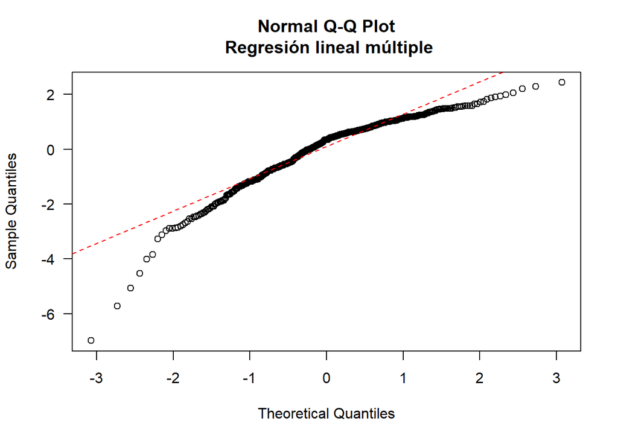

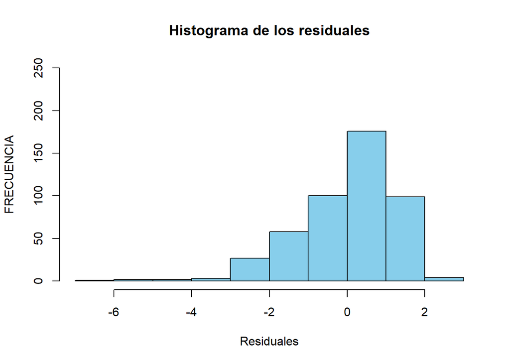

Como se puede ver en los gráficos anteriores, la variable respuesta presenta dos poblaciones diferentes, y el cambio o la diferencia entre estas dos poblaciones no se ha podido explicar con las variables elegidas en la modelación, el modelo elegido presenta una muy buena prediccion para los valores de satisfacción altos porque como es fácil inferir en estos niveles se están concentrando los pesos de la variable, pero presenta un mal ajuste para niveles bajos de satisfacción; es por esto que en el grafico de residuales vemos una cola inferior pesada y en el histograma vemos que los residuales se concentran en el lado derecho. Se modeló la variable respuesta de varias formas, una de ellas fue usando transformación cuyo objetivo es volver la variable respuesta constante alrededor de la media, luego se ajustó la distribución beta a la variable respuesta y se llegó a la misma conclusión, se optó por dejar el modelo mas parsimonioso.

# CONCLUSIONES: